# HW3

## EX1:

In this exercise I wanted to test the three cases of the master theorem. I did that by creating three differnet functions, apply a sorting alogrithm on them, calculate the runtime and compare the f(n) with log_b(a).

The three cases are:

1. The first case is when f(n) grows polynomially slower than log_b(a).
2. The second case is when f(n) grows at similar rates with log_b(a).
3. The third case is when f(n) grows polynomially faster than log_b(a).

Now, let's check the functions that I have worked on.

### In the first case:

This screen represents the first case runtime: T(n) = 1*T(n/2) + n

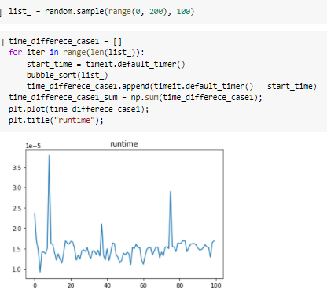

This screen represents the first case runtime: log_b(a)

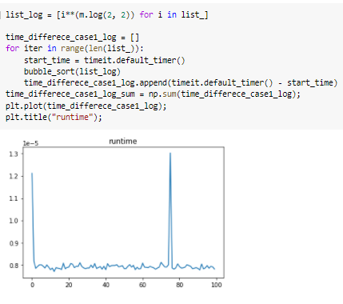

This screen represents the difference between the f(n) and the log_b(a) runtime differences.

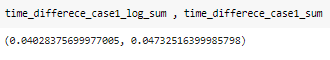

## In the second case:

I have created the input which was the squared root of the first random input then I also created the corresponding input for the log_b(a) input. then I applied the function on both of them then I calculated the runtime of both of them and compared and it turned out that actually both of the sum of their input is extremly similar. The runtime sum of the f(n) is (0.054434236999441055) and the runtime sum of the log_b(a) is (0.053413957000088885) which means that both of them at similar rates so that's why we choose the second case for this function.

This screen represents the second case runtime: T(n) = T(n) = 1*T(n/2) + n^2

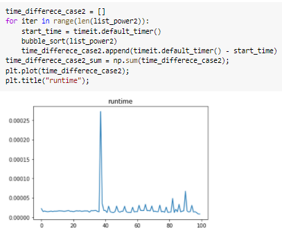

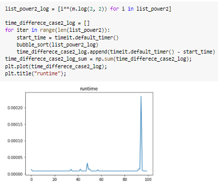

This screen represents the difference between the f(n) and the log_b(a) runtime differences.

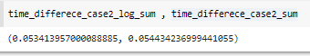

## In the third case:

I have created the input which was the random input **3 then I also created the corresponding input for the log_b(a) input. then I applied the sorting algorithm on both of them and calculated the runtime sum. It turned out that the runtime sum of f(n) is actually much faster (0.0008489269930578303) than the runtime sum of the log_b(a) (0.0018874850065913051) which means that this is this cases represents the third case.

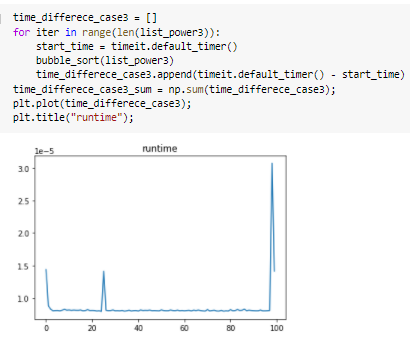

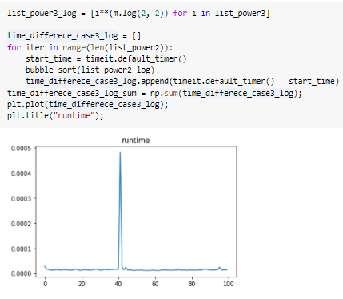

This screen represents the difference between the f(n) and the log_b(a) runtime differences.

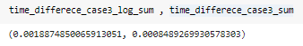

## EX2:

I will start this exercise by a question and an answer to that question. Can the Master theorem be applied on this function (T(n) = T(n/2) + n(sin(n - pi/2) + 2))? I would argue yes because we can use the n(sin(n - pi/2) + 2)) as an input to the function. This can be the itertive. In the sorting we will draw a tree and each time we will divide the input (n(sin(n - pi/2) + 2))) by the number of (a) so yes it's possible.

during the implementation of this function I chosed an upper and a lower bound for it. I divided the input by n as a lower bound and multiplyed it with an n as an upper bound.

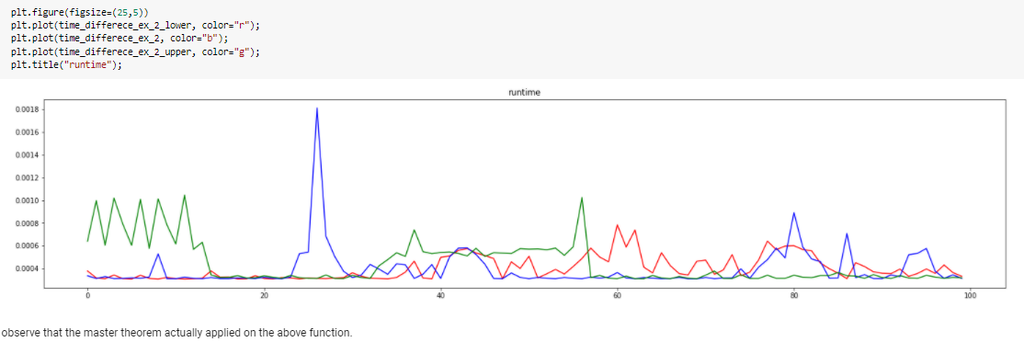

## EX3:

In this exercise I implemented my sorting algorithm on 8, 32, 64 bit unsigned (pseudo-)randomly generated integers. I applied the sorting algorithm on them then calculted the runtime and the sum of the runtime then I plotted them. It turned out that the 64 bit unsigned intgers has the highest runtime then the 32 bit then the 8 bit.

then I applied the built in sorting algorithm on the same 8, 32, 64 bit unsigned (pseudo-)randomly generated integers and it turned out that the built in algorithm is much much faster than my own implementation of the sorting algorithm. but at the same time there are differences in the runtime of the built-in function but the difference is not much.

Also, when trying to generate teh 64 bit unsigned (pseudo-)randomly generated integers. I got an error saying that Python int too large to convert to C ssize_t because 2**64-1 is too large to convert so what I will do is i'm gonna create another sample but the range will be larger than the 32 int sample and it went perfectly smooth from there.

This is the plot for the 8,32,64 bit unsigned random integers runtime:

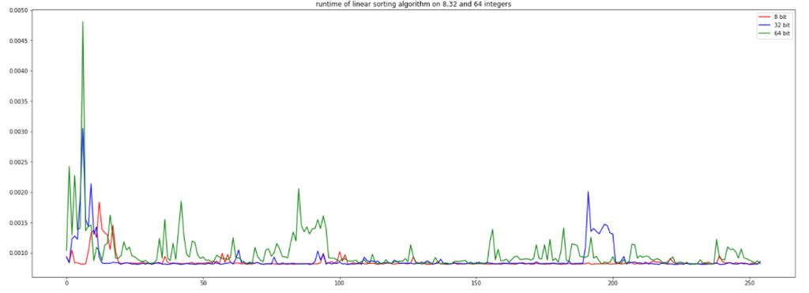

This is the plot for the 8,32,64 bit unsigned random integers runtime and the built-in sort algorithm:

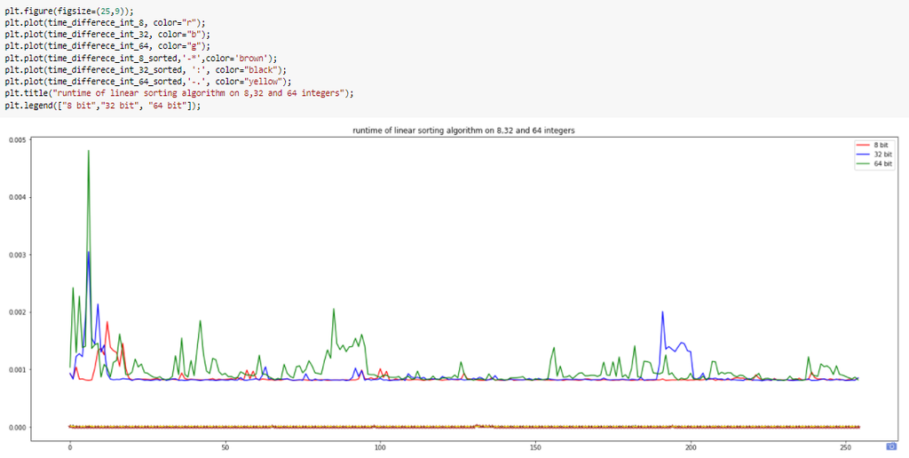

## EX4,5:

In this exercise I wanted to make my algorithm faster or as fast as the built-in sorting algorithm. so first I tested my algorithm and the built-in algorithm on a 100 random integers and I found that my algorithm was faster which didn't make any sense since I just tried it on the 8,32,64 bit integers and the built-in function was way faster than mine.

so I changed the input into a 1000 random integers and the true difference actually appeared. My algorithm was way was slower than the built in function. so I wanted to make it a bit faster by trying the following approachs:

This is the an experimental data implementation. I'm testing the runtime of the merge sort:

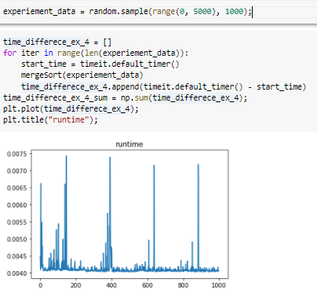

This is an implementation of the built-in sorted algorithm on the same dataset:

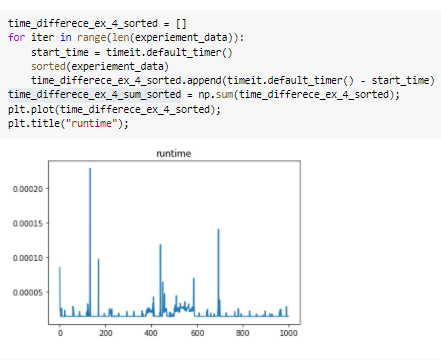

This is the difference between the two runtime:

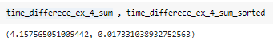

This is the implementation on the sorting algorithm:

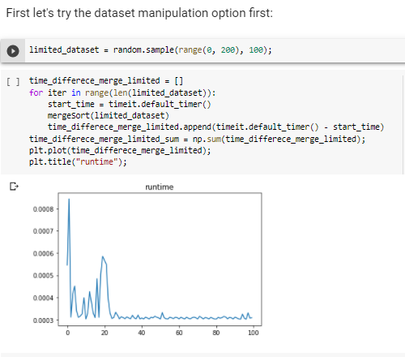

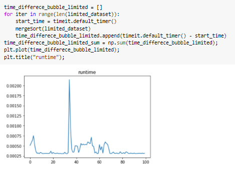

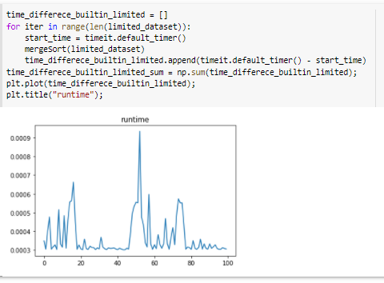

This is the difference between the three:

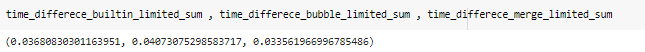

*Thus is another way to manipulate the function itself to make it in place which makes it much and much faster*

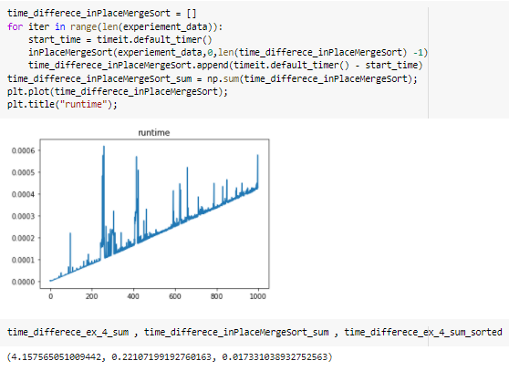

## EX6:

The next step was actually a really fun step which broke my laptop for half an hour :) In this step we wanted to break the in place merge sort and ruin the ruuntime for good. which better way to do so than give it a big random input data? In my analysis I found out that it's runtime gets ruined and I mean really ruined when the input is close to 1000000 so since we are using google colab not anaconda I said why not 4000000 and we said goodbye to the laptop for 29.88664140087761 minutes.

This is the screenshot where we are using the in place merge sort sorting function that I have already done in the previous step.

How I ruined it to pieces you may ask? I manipulated the dataset. as we can see in the screenshot the rutime was 30 minutes on an overseas server not a laptop or a computer so it's safe to say that the runtime of my function is long gone :)

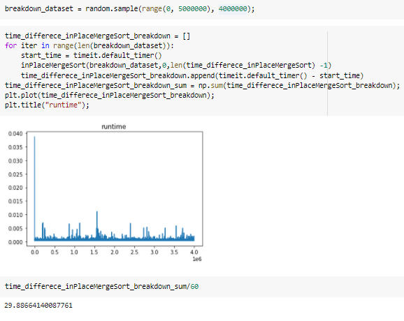

the things we do for science! :)